# hwk_5

Holden Jones

2025-04-08

```r
library(tidyverse)
library(GGally)
library(effects)
library(MASS)
fish <- read_csv('data/CRCP_fish.csv')
```

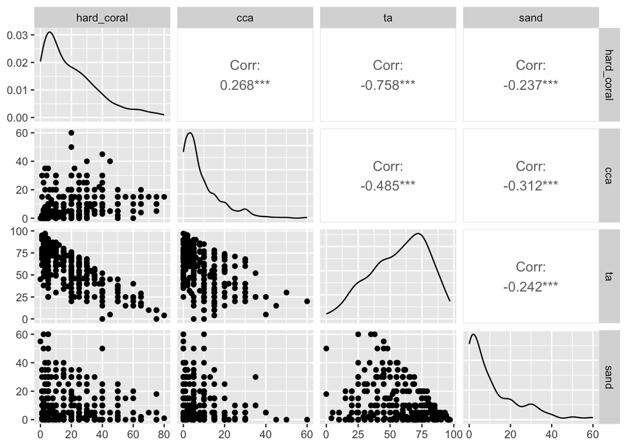

```r
compare_var <- ggpairs(fish, columns = c(17,20,21,22))
compare_var
```

#2. single predictor models for each predictor with kole count as response - use Poisson dist. - which predictors should be transformed to reduce skew? - based on dist. looks like hard_coral, cca, sand are very skewed

```r
fish <- fish %>%
  mutate(sqrt_hard_coral = sqrt(hard_coral),
         sqrt_sand = sqrt(sand),
         sqrt_cca = sqrt(cca))
```

check out these sqrt vars - doesn’t this make the vars closer to the normal dist? but it does reduce skew

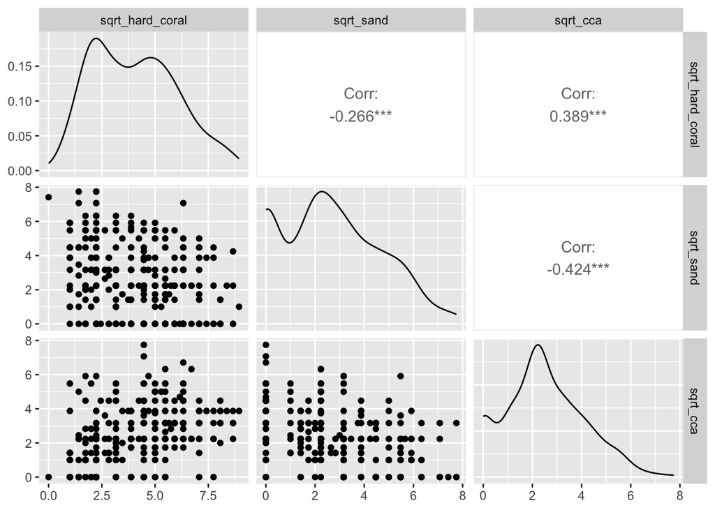

```r
compare_sqrt_var <- ggpairs(fish, columns = 48:50)
compare_sqrt_var
```

positive effect on kole count -hard_coral, cca

negative effect on kole count - sand, ta

```r
# hard_coral
glm_hard_coral <- glm(count ~ hard_coral, family = poisson, data = fish)
summary(glm_hard_coral) # hard_coral sig pos effect
```

```
##
## Call:
## glm(formula = count ~ hard_coral, family = poisson, data = fish)
##
## Coefficients:
##              Estimate Std. Error z value Pr(>|z|)
## (Intercept) 2.0379324  0.0257021   79.29   <2e-16 ***
## hard_coral  0.0243714  0.0006953   35.05   <2e-16 ***
## ---
## Signif. codes:  0 '***' 0.001 '**' 0.01 '*' 0.05 '.' 0.1 ' ' 1
##
## (Dispersion parameter for poisson family taken to be 1)
##
##     Null deviance: 7573.1  on 309  degrees of freedom
## Residual deviance: 6481.7  on 308  degrees of freedom
## AIC: 7402.7
##
## Number of Fisher Scoring iterations: 6
```

```r
glm_hard_coral_sqrt <- glm(count ~ sqrt_hard_coral, family = poisson,
                           data = fish)
summary(glm_hard_coral_sqrt) # sqrt hard_coral sig pos effect
```

```
##
## Call:
## glm(formula = count ~ sqrt_hard_coral, family = poisson, data = fish)
##
## Coefficients:
##                 Estimate Std. Error z value Pr(>|z|)
## (Intercept)     1.421071   0.041273   34.43   <2e-16 ***
## sqrt_hard_coral 0.266185   0.007494   35.52   <2e-16 ***
## ---
## Signif. codes:  0 '***' 0.001 '**' 0.01 '*' 0.05 '.' 0.1 ' ' 1
##
## (Dispersion parameter for poisson family taken to be 1)
##
##     Null deviance: 7573.1  on 309  degrees of freedom
## Residual deviance: 6313.0  on 308  degrees of freedom
## AIC: 7234
##
## Number of Fisher Scoring iterations: 6
```

```r
# sand
glm_sand <- glm(count ~ sand, family = poisson, data = fish)
summary(glm_sand) # sand sig neg effect
```

```
##
## Call:
## glm(formula = count ~ sand, family = poisson, data = fish)
##
## Coefficients:
##              Estimate Std. Error z value Pr(>|z|)
## (Intercept)  2.946727   0.018964  155.39   <2e-16 ***
## sand        -0.035770   0.001685  -21.22   <2e-16 ***
## ---
## Signif. codes:  0 '***' 0.001 '**' 0.01 '*' 0.05 '.' 0.1 ' ' 1
##
## (Dispersion parameter for poisson family taken to be 1)
##
##     Null deviance: 7573.1  on 309  degrees of freedom
## Residual deviance: 6998.7  on 308  degrees of freedom
## AIC: 7919.6
##
## Number of Fisher Scoring iterations: 6
```

```r
glm_sand_sqrt <- glm(count ~ sqrt_sand, family = poisson,
                           data = fish)
summary(glm_sand_sqrt) # sqrt sand sig neg effect
```

```
##
## Call:
## glm(formula = count ~ sqrt_sand, family = poisson, data = fish)
##
## Coefficients:
##              Estimate Std. Error z value Pr(>|z|)
## (Intercept)  3.101758   0.021722   142.8   <2e-16 ***
## sqrt_sand   -0.207975   0.008384   -24.8   <2e-16 ***
## ---
## Signif. codes:  0 '***' 0.001 '**' 0.01 '*' 0.05 '.' 0.1 ' ' 1
##
## (Dispersion parameter for poisson family taken to be 1)
##
##     Null deviance: 7573.1  on 309  degrees of freedom
## Residual deviance: 6904.5  on 308  degrees of freedom
## AIC: 7825.4
##
## Number of Fisher Scoring iterations: 6
```

```r
# cca
glm_cca <- glm(count ~ cca, family = poisson, data = fish)
summary(glm_cca) # cca sig pos effect
```

```
##
## Call:
## glm(formula = count ~ cca, family = poisson, data = fish)
##
## Coefficients:
##             Estimate Std. Error z value Pr(>|z|)
## (Intercept) 2.270516   0.021449  105.85   <2e-16 ***
## cca         0.034430   0.001153   29.85   <2e-16 ***
## ---
## Signif. codes:  0 '***' 0.001 '**' 0.01 '*' 0.05 '.' 0.1 ' ' 1
##
## (Dispersion parameter for poisson family taken to be 1)
##
##     Null deviance: 7573.1  on 309  degrees of freedom
## Residual deviance: 6846.7  on 308  degrees of freedom
## AIC: 7767.6
##
## Number of Fisher Scoring iterations: 6
```

```r
glm_cca_sqrt <- glm(count ~ sqrt_cca, family = poisson,
                           data = fish)
summary(glm_cca_sqrt) # sqrt cca sig pos effect
```

```
##
## Call:
## glm(formula = count ~ sqrt_cca, family = poisson, data = fish)
##
## Coefficients:
##             Estimate Std. Error z value Pr(>|z|)
## (Intercept) 1.762848   0.032938   53.52   <2e-16 ***
## sqrt_cca    0.302834   0.008778   34.50   <2e-16 ***
## ---
## Signif. codes:  0 '***' 0.001 '**' 0.01 '*' 0.05 '.' 0.1 ' ' 1
##
## (Dispersion parameter for poisson family taken to be 1)
##
##     Null deviance: 7573.1  on 309  degrees of freedom
## Residual deviance: 6426.7  on 308  degrees of freedom
## AIC: 7347.6
##
## Number of Fisher Scoring iterations: 6
```

```r
# ta - not transformed
glm_ta <- glm(count ~ ta, family = poisson, data = fish)
summary(glm_ta) # ta sig neg effect
```

```
##
## Call:
## glm(formula = count ~ ta, family = poisson, data = fish)
##
## Coefficients:
##               Estimate Std. Error z value Pr(>|z|)
## (Intercept)  3.5784202  0.0352931   101.4   <2e-16 ***
## ta          -0.0177069  0.0006581   -26.9   <2e-16 ***
## ---
## Signif. codes:  0 '***' 0.001 '**' 0.01 '*' 0.05 '.' 0.1 ' ' 1
##
## (Dispersion parameter for poisson family taken to be 1)
##
##     Null deviance: 7573.1  on 309  degrees of freedom
## Residual deviance: 6862.4  on 308  degrees of freedom
## AIC: 7783.4
##
## Number of Fisher Scoring iterations: 6
```

let’s look at overdispersion - every single model is extremely overdispersed - ideally dispersion would be 1 - most of these are about 30! even the transformed ones

```r
# make function for calculating dispersion
dispersion = function(model) {
  sum(residuals(model, type = "pearson")^2) / df.residual(model)
}

# calculate degree of dispersion for each model
dispersion(glm_hard_coral)
```

```
## [1] 28.13073
```

```r
dispersion(glm_hard_coral_sqrt)
```

```
## [1] 29.40857
```

```r
dispersion(glm_sand)
```

```
## [1] 30.97697
```

```r
dispersion(glm_sand_sqrt)
```

```
## [1] 30.64876
```

```r
dispersion(glm_ta)
```

```
## [1] 30.10215
```

```r
dispersion(glm_cca)
```

```
## [1] 30.8293
```

```r
dispersion(glm_cca_sqrt)
```

```
## [1] 29.15104
```

likelihood ratio tests for each model - the single predictor is significant in every single one of these likelihood ratio tests - I don’t like that I can’t see the sign or size of the effect

```r
anova(glm_hard_coral)
```

```
## Analysis of Deviance Table
##
## Model: poisson, link: log
##
## Response: count
##
## Terms added sequentially (first to last)
##
##
##            Df Deviance Resid. Df Resid. Dev  Pr(>Chi)
## NULL                         309     7573.1
## hard_coral  1   1091.4       308     6481.7 < 2.2e-16 ***
## ---
## Signif. codes:  0 '***' 0.001 '**' 0.01 '*' 0.05 '.' 0.1 ' ' 1
```

```r
anova(glm_hard_coral_sqrt)
```

```
## Analysis of Deviance Table
##
## Model: poisson, link: log
##
## Response: count
##
## Terms added sequentially (first to last)
##
##
##                 Df Deviance Resid. Df Resid. Dev  Pr(>Chi)
## NULL                              309     7573.1
## sqrt_hard_coral  1   1260.1       308     6313.0 < 2.2e-16 ***
## ---
## Signif. codes:  0 '***' 0.001 '**' 0.01 '*' 0.05 '.' 0.1 ' ' 1
```

```r
anova(glm_sand)
```

```
## Analysis of Deviance Table
##
## Model: poisson, link: log
##
## Response: count
##
## Terms added sequentially (first to last)
##
##
##      Df Deviance Resid. Df Resid. Dev  Pr(>Chi)
## NULL                   309     7573.1
## sand  1   574.42       308     6998.7 < 2.2e-16 ***
## ---
## Signif. codes:  0 '***' 0.001 '**' 0.01 '*' 0.05 '.' 0.1 ' ' 1
```

```r
anova(glm_sand_sqrt)
```

```
## Analysis of Deviance Table
##
## Model: poisson, link: log
##
## Response: count
##
## Terms added sequentially (first to last)
##
##
##           Df Deviance Resid. Df Resid. Dev  Pr(>Chi)
## NULL                        309     7573.1
## sqrt_sand  1   668.66       308     6904.5 < 2.2e-16 ***
## ---
## Signif. codes:  0 '***' 0.001 '**' 0.01 '*' 0.05 '.' 0.1 ' ' 1
```

```r
anova(glm_ta)
```

```
## Analysis of Deviance Table
##
## Model: poisson, link: log
##
## Response: count
##
## Terms added sequentially (first to last)
##
##
##      Df Deviance Resid. Df Resid. Dev  Pr(>Chi)
## NULL                   309     7573.1
## ta    1   710.68       308     6862.4 < 2.2e-16 ***
## ---
## Signif. codes:  0 '***' 0.001 '**' 0.01 '*' 0.05 '.' 0.1 ' ' 1
```

```r
anova(glm_cca)
```

```
## Analysis of Deviance Table
##
## Model: poisson, link: log
##
## Response: count
##
## Terms added sequentially (first to last)
##
##
##      Df Deviance Resid. Df Resid. Dev  Pr(>Chi)
## NULL                   309     7573.1
## cca   1   726.46       308     6846.7 < 2.2e-16 ***
## ---
## Signif. codes:  0 '***' 0.001 '**' 0.01 '*' 0.05 '.' 0.1 ' ' 1
```

```r
anova(glm_cca_sqrt)
```

```
## Analysis of Deviance Table
##
## Model: poisson, link: log
##
## Response: count
##
## Terms added sequentially (first to last)
##
##
##          Df Deviance Resid. Df Resid. Dev  Pr(>Chi)
## NULL                       309     7573.1
## sqrt_cca  1   1146.4       308     6426.7 < 2.2e-16 ***
## ---
## Signif. codes:  0 '***' 0.001 '**' 0.01 '*' 0.05 '.' 0.1 ' ' 1
```

make effects plots to investigate size and sign of effects - hard_coral has positive effect on count - sand has negative effect on count - ta has negative effect on count - cca has positive effect on count

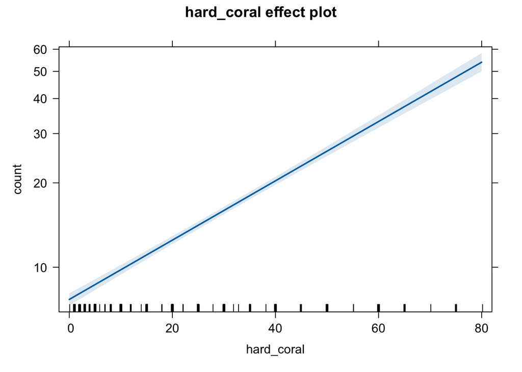

```r
plot(allEffects(glm_hard_coral))
```

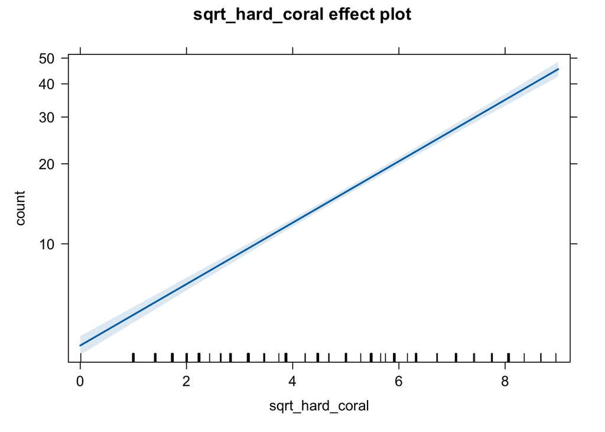

```r
plot(allEffects(glm_hard_coral_sqrt))
```

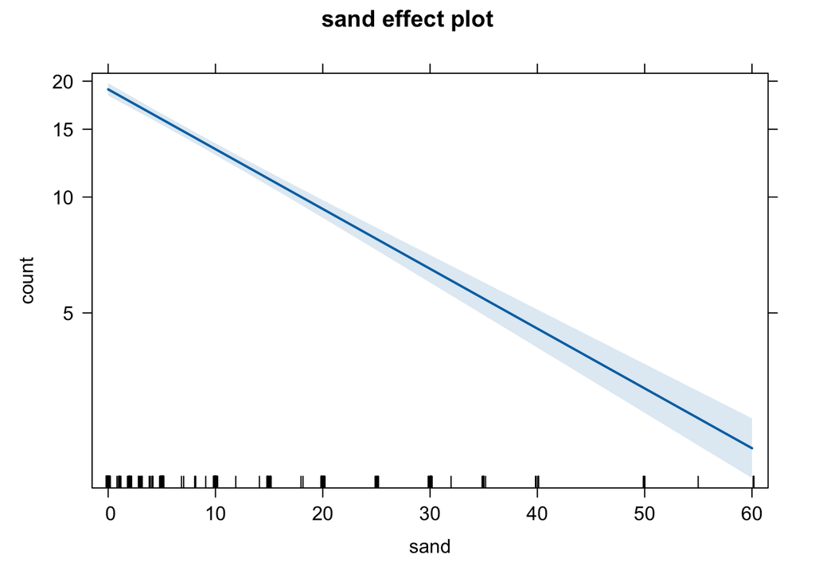

```r
plot(allEffects(glm_sand))
```

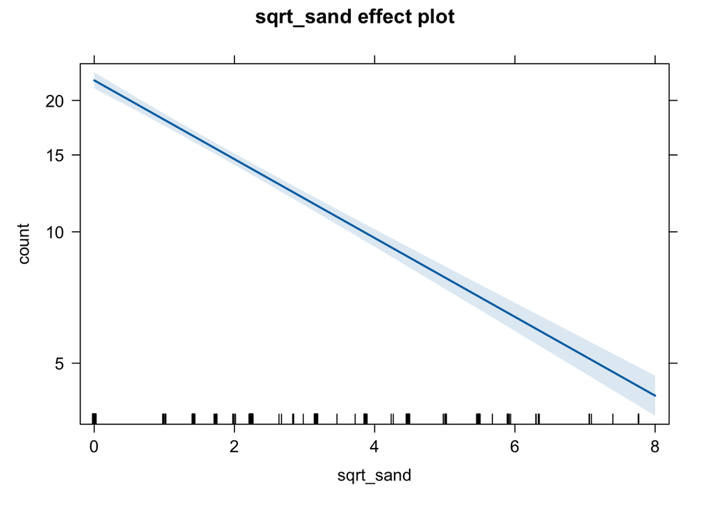

```r
plot(allEffects(glm_sand_sqrt))
```

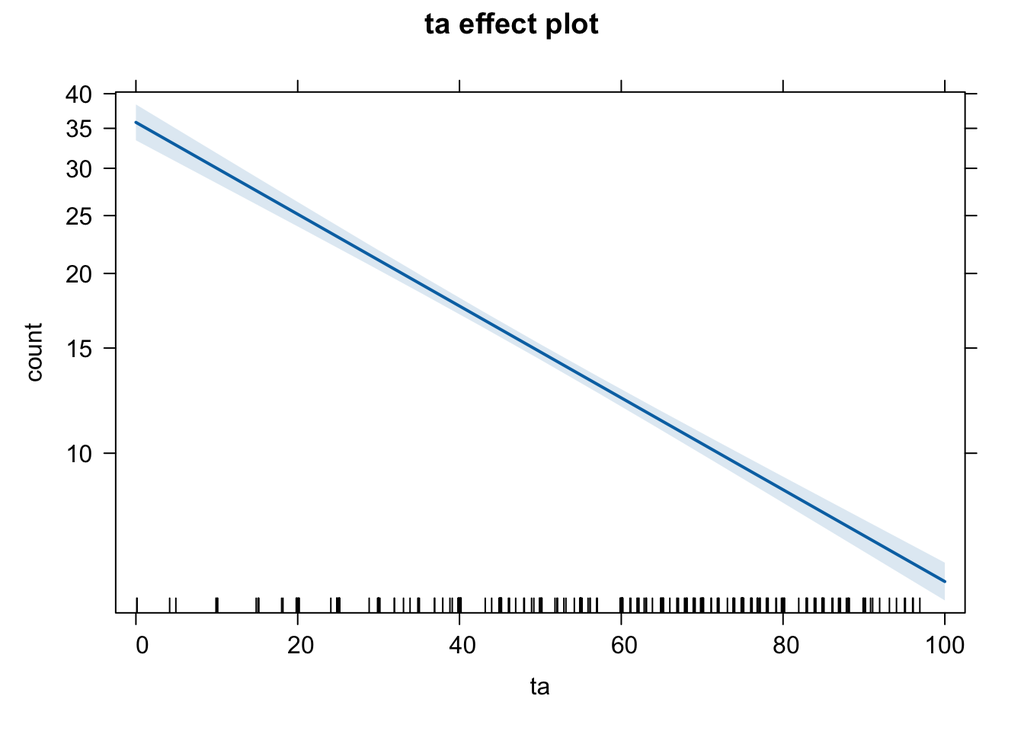

```r
plot(allEffects(glm_ta))
```

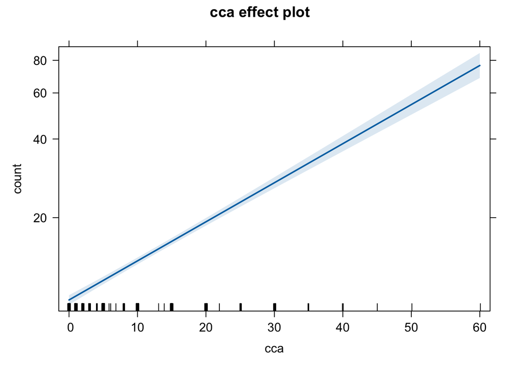

```r
plot(allEffects(glm_cca))
```

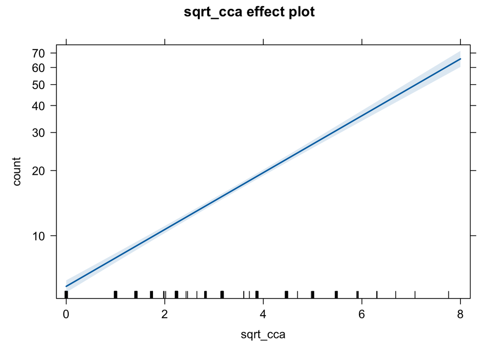

```r
plot(allEffects(glm_cca_sqrt))
```

#3. use negative binomial distribution when Poisson dist. is overdispersed - re run every model changing family to negative binomial - need to use glm.nb() from MASS package

```r
# hard_coral
glm_hard_coral <- glm.nb(count ~ hard_coral, data = fish)
summary(glm_hard_coral) # hard_coral sig pos effect
```

```
##
## Call:
## glm.nb(formula = count ~ hard_coral, data = fish, init.theta = 0.3931303705,
##     link = log)
##
## Coefficients:
##             Estimate Std. Error z value Pr(>|z|)
## (Intercept) 1.858032   0.140369  13.237  < 2e-16 ***
## hard_coral  0.031720   0.005176   6.129 8.86e-10 ***
## ---
## Signif. codes:  0 '***' 0.001 '**' 0.01 '*' 0.05 '.' 0.1 ' ' 1
##
## (Dispersion parameter for Negative Binomial(0.3931) family taken to be 1)
##
##     Null deviance: 379.65  on 309  degrees of freedom
## Residual deviance: 346.22  on 308  degrees of freedom
## AIC: 2072.6
##
## Number of Fisher Scoring iterations: 1
##
##
##               Theta:  0.3931
##           Std. Err.:  0.0344
##
##  2 x log-likelihood:  -2066.6070
```

```r
glm_hard_coral_sqrt <- glm.nb(count ~ sqrt_hard_coral, data = fish)
summary(glm_hard_coral_sqrt) # sqrt hard_coral sig pos effect
```

```
##
## Call:
## glm.nb(formula = count ~ sqrt_hard_coral, data = fish, init.theta = 0.39938723,
##     link = log)
##
## Coefficients:
##                 Estimate Std. Error z value Pr(>|z|)
## (Intercept)      1.28651    0.21146   6.084 1.17e-09 ***
## sqrt_hard_coral  0.29523    0.04672   6.320 2.62e-10 ***
## ---
## Signif. codes:  0 '***' 0.001 '**' 0.01 '*' 0.05 '.' 0.1 ' ' 1
##
## (Dispersion parameter for Negative Binomial(0.3994) family taken to be 1)
##
##     Null deviance: 384.51  on 309  degrees of freedom
## Residual deviance: 346.34  on 308  degrees of freedom
## AIC: 2068.4
##
## Number of Fisher Scoring iterations: 1
##
##
##               Theta:  0.3994
##           Std. Err.:  0.0351
##
##  2 x log-likelihood:  -2062.4170
```

```r
# sand
glm_sand <- glm.nb(count ~ sand, data = fish)
summary(glm_sand) # sand sig neg effect
```

```
##
## Call:
## glm.nb(formula = count ~ sand, data = fish, init.theta = 0.3729581071,
##     link = log)
##
## Coefficients:
##              Estimate Std. Error z value Pr(>|z|)
## (Intercept)  2.941783   0.124216   23.68  < 2e-16 ***
## sand        -0.035008   0.007544   -4.64 3.48e-06 ***
## ---
## Signif. codes:  0 '***' 0.001 '**' 0.01 '*' 0.05 '.' 0.1 ' ' 1
##
## (Dispersion parameter for Negative Binomial(0.373) family taken to be 1)
##
##     Null deviance: 363.85  on 309  degrees of freedom
## Residual deviance: 345.96  on 308  degrees of freedom
## AIC: 2086.9
##
## Number of Fisher Scoring iterations: 1
##
##
##               Theta:  0.3730
##           Std. Err.:  0.0323
##
##  2 x log-likelihood:  -2080.8530
```

```r
glm_sand_sqrt <- glm.nb(count ~ sqrt_sand, data = fish)
summary(glm_sand_sqrt) # sqrt sand sig neg effect
```

```
##
## Call:
## glm.nb(formula = count ~ sqrt_sand, data = fish, init.theta = 0.3741466173,
##     link = log)
##
## Coefficients:
##             Estimate Std. Error z value Pr(>|z|)
## (Intercept)  3.10793    0.15416  20.160  < 2e-16 ***
## sqrt_sand   -0.21043    0.04701  -4.476 7.61e-06 ***
## ---
## Signif. codes:  0 '***' 0.001 '**' 0.01 '*' 0.05 '.' 0.1 ' ' 1
##
## (Dispersion parameter for Negative Binomial(0.3741) family taken to be 1)
##
##     Null deviance: 364.79  on 309  degrees of freedom
## Residual deviance: 346.10  on 308  degrees of freedom
## AIC: 2086.1
##
## Number of Fisher Scoring iterations: 1
##
##
##               Theta:  0.3741
##           Std. Err.:  0.0324
##
##  2 x log-likelihood:  -2080.1090
```

```r
# cca
glm_cca <- glm.nb(count ~ cca, data = fish)
summary(glm_cca) # cca sig pos effect
```

```
##
## Call:
## glm.nb(formula = count ~ cca, data = fish, init.theta = 0.3839858353,
##     link = log)
##
## Coefficients:
##             Estimate Std. Error z value Pr(>|z|)
## (Intercept) 1.999507   0.126584  15.796  < 2e-16 ***
## cca         0.060098   0.009659   6.222 4.91e-10 ***
## ---
## Signif. codes:  0 '***' 0.001 '**' 0.01 '*' 0.05 '.' 0.1 ' ' 1
##
## (Dispersion parameter for Negative Binomial(0.384) family taken to be 1)
##
##     Null deviance: 372.51  on 309  degrees of freedom
## Residual deviance: 345.99  on 308  degrees of freedom
## AIC: 2078.8
##
## Number of Fisher Scoring iterations: 1
##
##
##               Theta:  0.3840
##           Std. Err.:  0.0334
##
##  2 x log-likelihood:  -2072.8340
```

```r
glm_cca_sqrt <- glm.nb(count ~ sqrt_cca, data = fish)
summary(glm_cca_sqrt) # sqrt cca sig pos effect
```

```
##
## Call:
## glm.nb(formula = count ~ sqrt_cca, data = fish, init.theta = 0.4066505704,
##     link = log)
##
## Coefficients:
##             Estimate Std. Error z value Pr(>|z|)
## (Intercept)  1.39493    0.16861   8.273  < 2e-16 ***
## sqrt_cca     0.42920    0.05641   7.609 2.77e-14 ***
## ---
## Signif. codes:  0 '***' 0.001 '**' 0.01 '*' 0.05 '.' 0.1 ' ' 1
##
## (Dispersion parameter for Negative Binomial(0.4067) family taken to be 1)
##
##     Null deviance: 390.13  on 309  degrees of freedom
## Residual deviance: 346.00  on 308  degrees of freedom
## AIC: 2063.2
##
## Number of Fisher Scoring iterations: 1
##
##
##               Theta:  0.4067
##           Std. Err.:  0.0359
##
##  2 x log-likelihood:  -2057.1730
```

```r
# ta - not transformed
glm_ta <- glm.nb(count ~ ta, data = fish)
summary(glm_ta) # ta sig neg effect
```

```
##
## Call:
## glm.nb(formula = count ~ ta, data = fish, init.theta = 0.3750484251,
##     link = log)
##
## Coefficients:
##             Estimate Std. Error z value Pr(>|z|)
## (Intercept)  3.64697    0.26206   13.92  < 2e-16 ***
## ta          -0.01900    0.00427   -4.45 8.57e-06 ***
## ---
## Signif. codes:  0 '***' 0.001 '**' 0.01 '*' 0.05 '.' 0.1 ' ' 1
##
## (Dispersion parameter for Negative Binomial(0.375) family taken to be 1)
##
##     Null deviance: 365.50  on 309  degrees of freedom
## Residual deviance: 346.15  on 308  degrees of freedom
## AIC: 2085.5
##
## Number of Fisher Scoring iterations: 1
##
##
##               Theta:  0.3750
##           Std. Err.:  0.0325
##
##  2 x log-likelihood:  -2079.4990
```

calculate degree of dispersion for these new neg binomial models - that’s more like it! this is now appropriate for interpretation - dispersion parameter approximately equal to 1 (way better than 30) - the negative binomial fits the data much better than the Poisson dist.

```r
dispersion(glm_hard_coral)
```

```
## [1] 1.075455
```

```r
dispersion(glm_hard_coral_sqrt)
```

```
## [1] 1.312868
```

```r
dispersion(glm_sand)
```

```
## [1] 0.9493442
```

```r
dispersion(glm_sand_sqrt)
```

```
## [1] 0.9688957
```

```r
dispersion(glm_ta)
```

```
## [1] 0.9872545
```

```r
dispersion(glm_cca)
```

```
## [1] 1.03896
```

```r
dispersion(glm_cca_sqrt)
```

```
## [1] 1.135998
```

likelihood ratio tests for each of these negative binomial models as well

```r
anova(glm_hard_coral)
```

```
## Analysis of Deviance Table
##
## Model: Negative Binomial(0.3931), link: log
##
## Response: count
##
## Terms added sequentially (first to last)
##
##
##            Df Deviance Resid. Df Resid. Dev  Pr(>Chi)
## NULL                         309     379.65
## hard_coral  1   33.437       308     346.22 7.363e-09 ***
## ---
## Signif. codes:  0 '***' 0.001 '**' 0.01 '*' 0.05 '.' 0.1 ' ' 1
```

```r
anova(glm_hard_coral_sqrt)
```

```
## Analysis of Deviance Table
##
## Model: Negative Binomial(0.3994), link: log
##
## Response: count
##
## Terms added sequentially (first to last)
##
##
##                 Df Deviance Resid. Df Resid. Dev  Pr(>Chi)
## NULL                              309     384.51
## sqrt_hard_coral  1   38.173       308     346.34 6.475e-10 ***
## ---
## Signif. codes:  0 '***' 0.001 '**' 0.01 '*' 0.05 '.' 0.1 ' ' 1
```

```r
anova(glm_sand)
```

```
## Analysis of Deviance Table
##
## Model: Negative Binomial(0.373), link: log
##
## Response: count
##
## Terms added sequentially (first to last)
##
##
##      Df Deviance Resid. Df Resid. Dev  Pr(>Chi)
## NULL                   309     363.85
## sand  1   17.888       308     345.96 2.343e-05 ***
## ---
## Signif. codes:  0 '***' 0.001 '**' 0.01 '*' 0.05 '.' 0.1 ' ' 1
```

```r
anova(glm_sand_sqrt)
```

```
## Analysis of Deviance Table
##
## Model: Negative Binomial(0.3741), link: log
##
## Response: count
##
## Terms added sequentially (first to last)
##
##
##           Df Deviance Resid. Df Resid. Dev Pr(>Chi)
## NULL                        309     364.79
## sqrt_sand  1   18.688       308     346.10 1.54e-05 ***
## ---
## Signif. codes:  0 '***' 0.001 '**' 0.01 '*' 0.05 '.' 0.1 ' ' 1
```

```r
anova(glm_ta)
```

```
## Analysis of Deviance Table
##
## Model: Negative Binomial(0.375), link: log
##
## Response: count
##
## Terms added sequentially (first to last)
##
##
##      Df Deviance Resid. Df Resid. Dev  Pr(>Chi)
## NULL                   309     365.50
## ta    1   19.342       308     346.15 1.093e-05 ***
## ---
## Signif. codes:  0 '***' 0.001 '**' 0.01 '*' 0.05 '.' 0.1 ' ' 1
```

```r
anova(glm_cca)
```

```
## Analysis of Deviance Table
##
## Model: Negative Binomial(0.384), link: log
##
## Response: count
##
## Terms added sequentially (first to last)
##
##
##      Df Deviance Resid. Df Resid. Dev  Pr(>Chi)
## NULL                   309     372.51
## cca   1   26.529       308     345.99 2.597e-07 ***
## ---
## Signif. codes:  0 '***' 0.001 '**' 0.01 '*' 0.05 '.' 0.1 ' ' 1
```

```r
anova(glm_cca_sqrt)
```

```
## Analysis of Deviance Table
##
## Model: Negative Binomial(0.4067), link: log
##
## Response: count
##
## Terms added sequentially (first to last)
##
##
##          Df Deviance Resid. Df Resid. Dev  Pr(>Chi)
## NULL                       309     390.13
## sqrt_cca  1   44.131       308     346.00 3.071e-11 ***
## ---
## Signif. codes:  0 '***' 0.001 '**' 0.01 '*' 0.05 '.' 0.1 ' ' 1
```

look at effects plots for new models

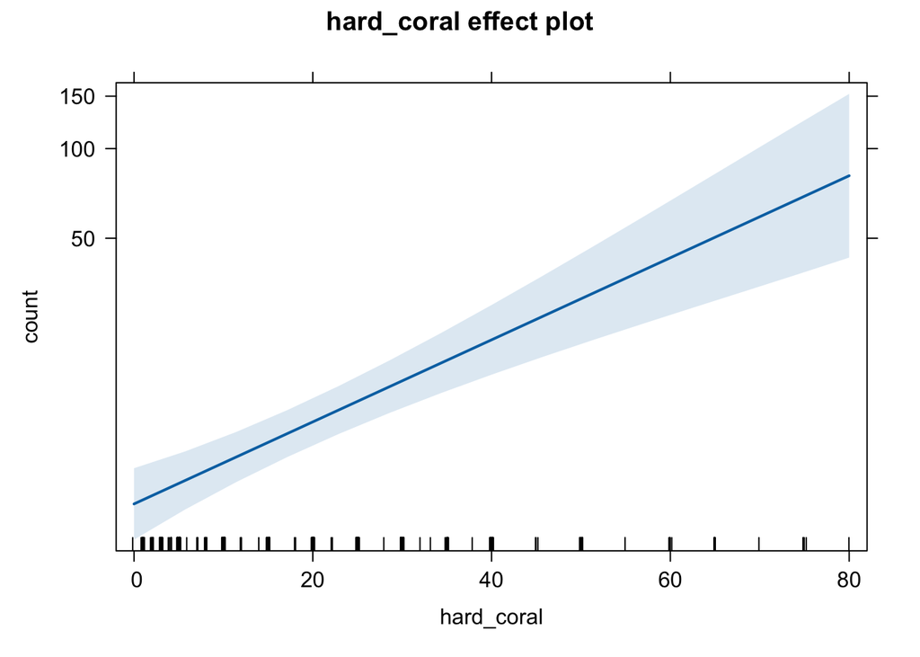

```r
plot(allEffects(glm_hard_coral))
```

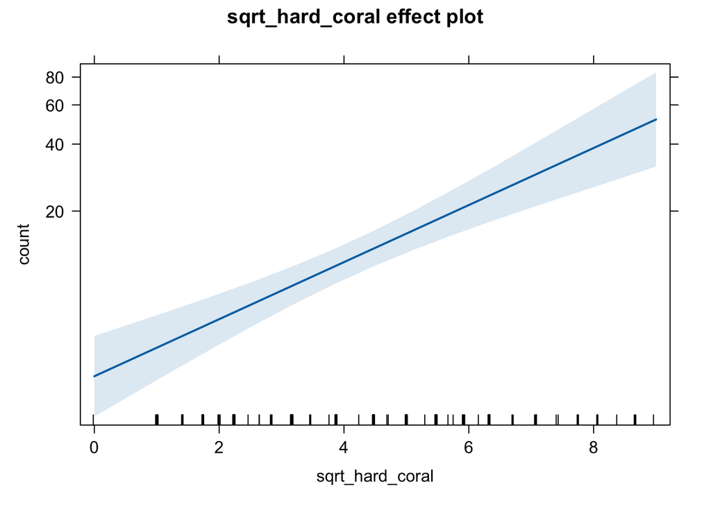

```r
plot(allEffects(glm_hard_coral_sqrt))
```

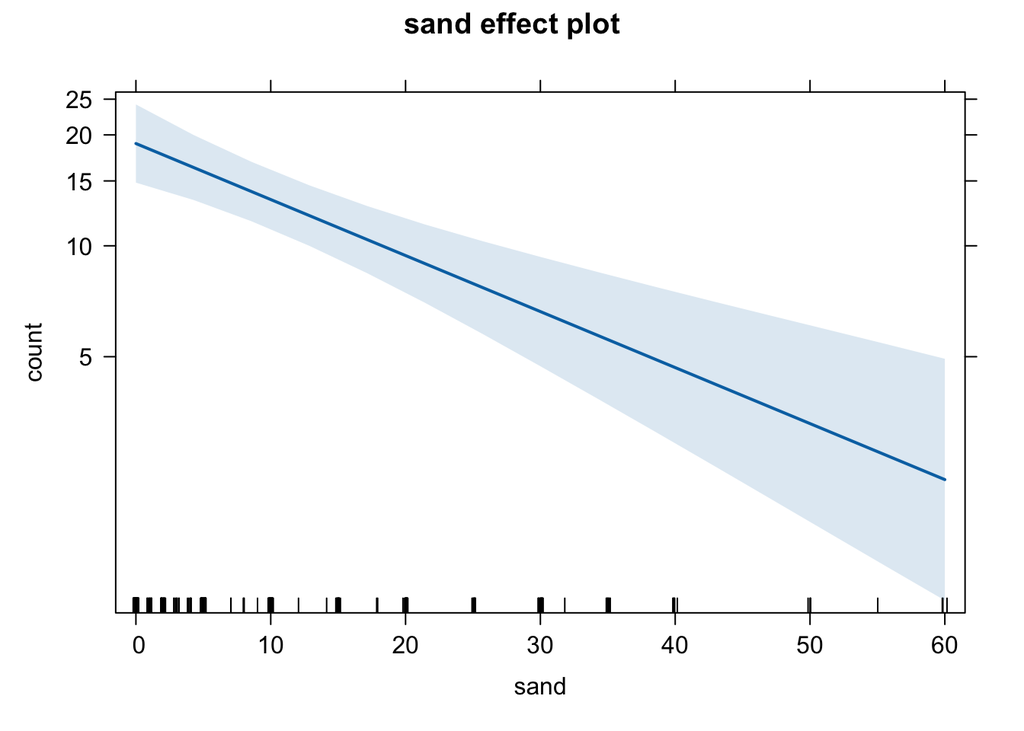

```r
plot(allEffects(glm_sand))
```

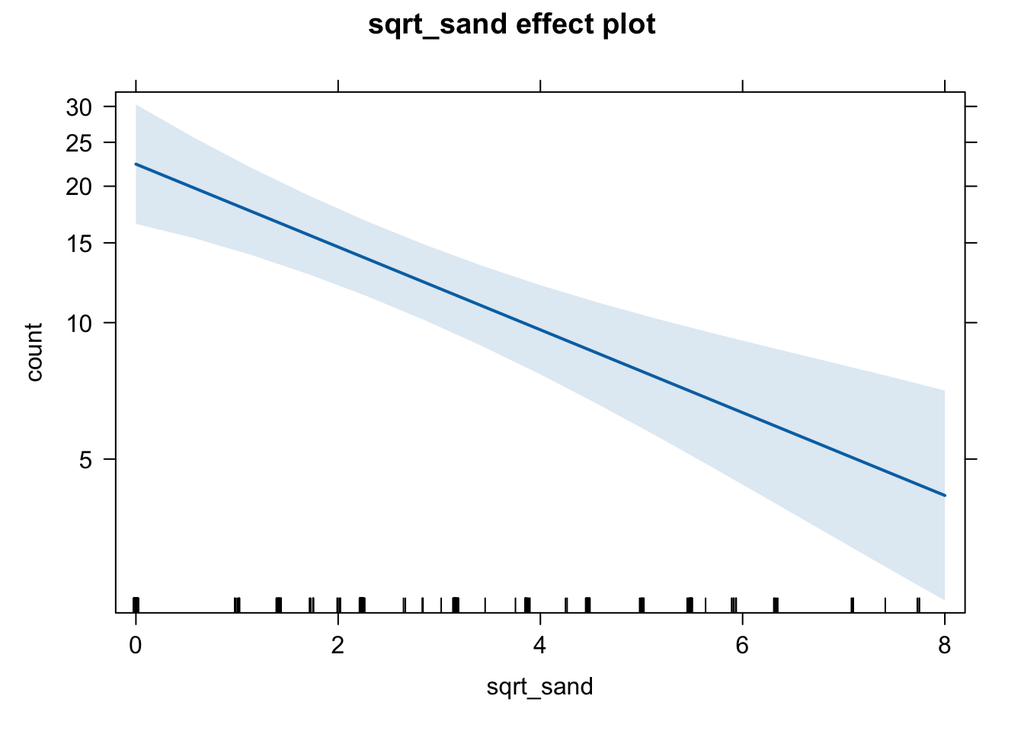

```r
plot(allEffects(glm_sand_sqrt))
```

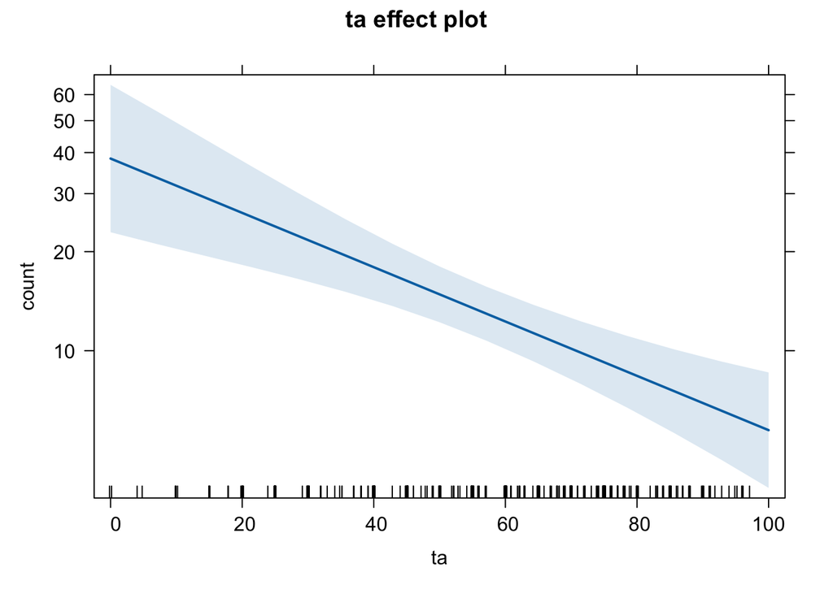

```r
plot(allEffects(glm_ta))
```

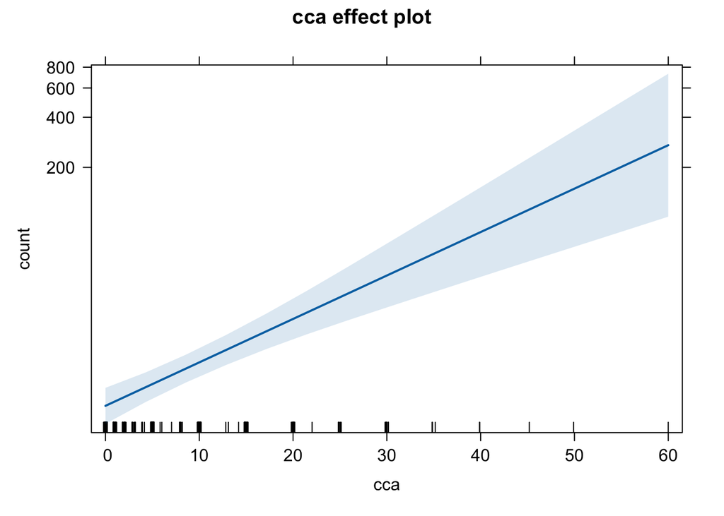

```r
plot(allEffects(glm_cca))
```

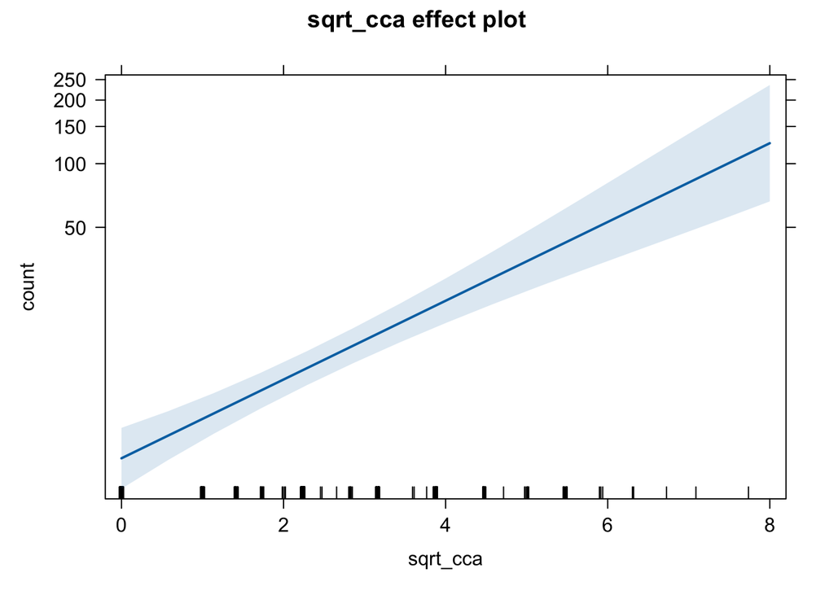

```r
plot(allEffects(glm_cca_sqrt))
```

This new round of negative binomial models fits the data much better. - These negative binomial models are no longer overdispersed - The overall findings are still the same (hard_coral, cca sig pos; sand, ta sig neg) - It appears that square root transforming skewed variables is no longer necessary minimal difference in model fit between transformed and non-transformed models

#4.

make full model with multiple substrate types - not using transformed vars per earlier observation

```r
glm_full <- glm.nb(count ~ hard_coral + sand + cca + ta, data = fish)
summary(glm_full) # hard_coral sig pos, cca sig pos, ta sig pos
```

```
##
## Call:
## glm.nb(formula = count ~ hard_coral + sand + cca + ta, data = fish,
##     init.theta = 0.4547766048, link = log)
##
## Coefficients:
##             Estimate Std. Error z value Pr(>|z|)
## (Intercept) -2.85507    1.66061  -1.719  0.08556 .
## hard_coral   0.07439    0.01716   4.336 1.45e-05 ***
## sand         0.01835    0.01825   1.006  0.31453
## cca          0.09260    0.02028   4.566 4.96e-06 ***
## ta           0.04659    0.01703   2.736  0.00622 **
## ---
## Signif. codes:  0 '***' 0.001 '**' 0.01 '*' 0.05 '.' 0.1 ' ' 1
##
## (Dispersion parameter for Negative Binomial(0.4548) family taken to be 1)
##
##     Null deviance: 426.74  on 309  degrees of freedom
## Residual deviance: 345.03  on 305  degrees of freedom
## AIC: 2038.2
##
## Number of Fisher Scoring iterations: 1
##
##
##               Theta:  0.4548
##           Std. Err.:  0.0410
##
##  2 x log-likelihood:  -2026.2040
```

likelihood ratio tests and effects plots

```r
dispersion(glm_full)
```

```
## [1] 1.512709
```

```r
anova(glm_full)
```

```
## Analysis of Deviance Table
##
## Model: Negative Binomial(0.4548), link: log
##
## Response: count
##
## Terms added sequentially (first to last)
##
##
##            Df Deviance Resid. Df Resid. Dev  Pr(>Chi)
## NULL                         309     426.74
## hard_coral  1   38.480       308     388.26 5.531e-10 ***
## sand        1   18.573       307     369.68 1.635e-05 ***
## cca         1   18.369       306     351.31 1.820e-05 ***
## ta          1    6.289       305     345.03   0.01215 *
## ---
## Signif. codes:  0 '***' 0.001 '**' 0.01 '*' 0.05 '.' 0.1 ' ' 1
```

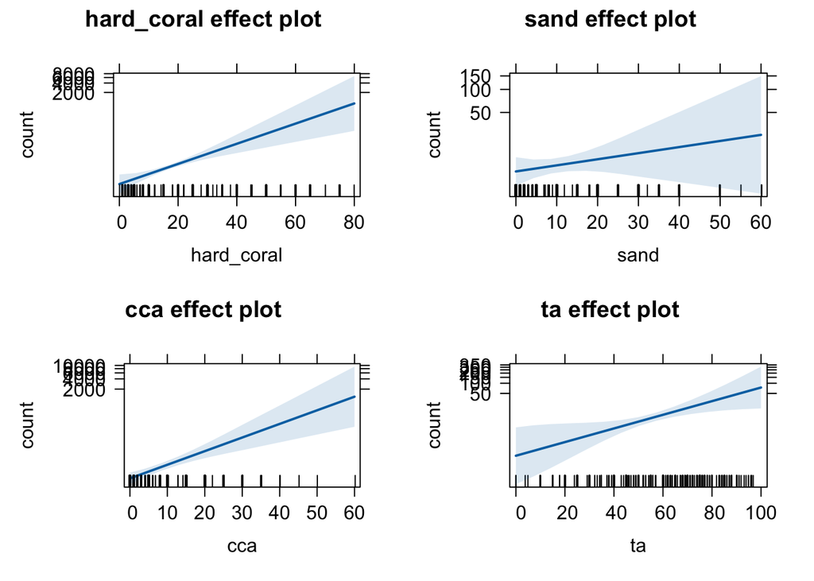

```r
plot(allEffects(glm_full))
```

overall conclusions - with the full model it now appears that all substrates have a positive effect on counts? This does seem a bit unlikely. - this full model is not overdispersed (although it’s close to limit) - I don’t feel the need to run any more analyses, time for dinner!